# многофакторные регрессионные уравнения

# Многофакторные регрессионные уравнения

Ход работы:

1. Загрузка данных:

price - это цена бриллианта в долларах США.  
carat - это вес бриллианта.  
cut - это качество огранки (удовлетворительное, хорошее, очень хорошее, премиум, идеальное).  
color, от J (худший) до D (лучший). измерение чистоты алмаза (I1 (наихудший), SI2, SI1, VS2, VS1, VVS2, VVS1, IF (лучший))  
X - длина в мм  
Y - ширина в мм  
Z - глубина в мм  
depth - общая глубина в процентах  
table - ширина вершины алмаза относительно самой широкой точки

```r
z <- read.csv(file = "diamonds.csv", header = TRUE, sep = ",", dec =".")
str(z)
```

```
## 'data.frame':    53940 obs. of  11 variables:
##  $ X      : int  1 2 3 4 5 6 7 8 9 10 ...
##  $ carat  : num  0.23 0.21 0.23 0.29 0.31 0.24 0.24 0.26 0.22 0.23 ...
##  $ cut    : Factor w/ 5 levels "Fair","Good",..: 3 4 2 4 2 5 5 5 1 5 ...
##  $ color  : Factor w/ 7 levels "D","E","F","G",..: 2 2 2 6 7 7 6 5 2 5 ...
##  $ clarity: Factor w/ 8 levels "I1","IF","SI1",..: 4 3 5 6 4 8 7 3 6 5 ...
##  $ depth  : num  61.5 59.8 56.9 62.4 63.3 62.8 62.3 61.9 65.1 59.4 ...
##  $ table  : num  55 61 65 58 58 57 57 55 61 61 ...
##  $ price  : int  326 326 327 334 335 336 336 337 337 338 ...
##  $ x      : num  3.95 3.89 4.05 4.2 4.34 3.94 3.95 4.07 3.87 4 ...
##  $ y      : num  3.98 3.84 4.07 4.23 4.35 3.96 3.98 4.11 3.78 4.05 ...
##  $ z      : num  2.43 2.31 2.31 2.63 2.75 2.48 2.47 2.53 2.49 2.39 ...
```

**[NA значения]**

```r
sapply(z, function(x) sum(is.na(x)))
```

```
##       X   carat     cut   color clarity   depth   table   price       x
##       0       0       0       0       0       0       0       0       0
##       y       z
##       0       0
```

2. Подготовка данных:

```r
vars <- names(z) %in% c("x", "y", "z")
data <- z[vars]
vol<-data$z*data$x*data$y
myvars <- names(z) %in% c("carat", "depth","table", "price")
mydata <- z[myvars]
mydata$volume<-vol
set.seed(27)
split0 <- sample.split(mydata, SplitRatio = 0.3)
mydata <- subset(mydata, split0 == TRUE)
litdata <- subset(mydata, split0 == TRUE)
str(mydata)
```

```
## 'data.frame':    10788 obs. of  5 variables:
##  $ carat : num  0.21 0.24 0.23 0.3 0.23 0.24 0.23 0.23 0.33 0.32 ...
##  $ depth : num  59.8 62.3 62.8 62 63.8 62.5 59.8 64.1 61.1 61.8 ...
##  $ table : num  61 57 56 54 55 57 57 59 56 55 ...
##  $ price : int  326 336 340 348 352 355 402 402 403 403 ...
##  $ volume: num  34.5 38.8 37.7 50.1 37.4 ...
```

```r
corr.test(mydata)
```

```
## Call:corr.test(x = mydata)
## Correlation matrix
##        carat depth table price volume
## carat   1.00  0.03  0.18  0.92   1.00
## depth   0.03  1.00 -0.30 -0.02   0.01
## table   0.18 -0.30  1.00  0.13   0.17
## price   0.92 -0.02  0.13  1.00   0.92
## volume  1.00  0.01  0.17  0.92   1.00
## Sample Size
## [1] 10788
## Probability values (Entries above the diagonal are adjusted for multiple tests.)
##        carat depth table price volume
## carat   0.00  0.03     0  0.00   0.00
## depth   0.01  0.00     0  0.24   0.38
## table   0.00  0.00     0  0.00   0.00
## price   0.00  0.12     0  0.00   0.00
## volume  0.00  0.38     0  0.00   0.00
##
##  To see confidence intervals of the correlations, print with the short=FALSE option
```

[figure not shown]

```r
corrgram(mydata, order=TRUE)
```

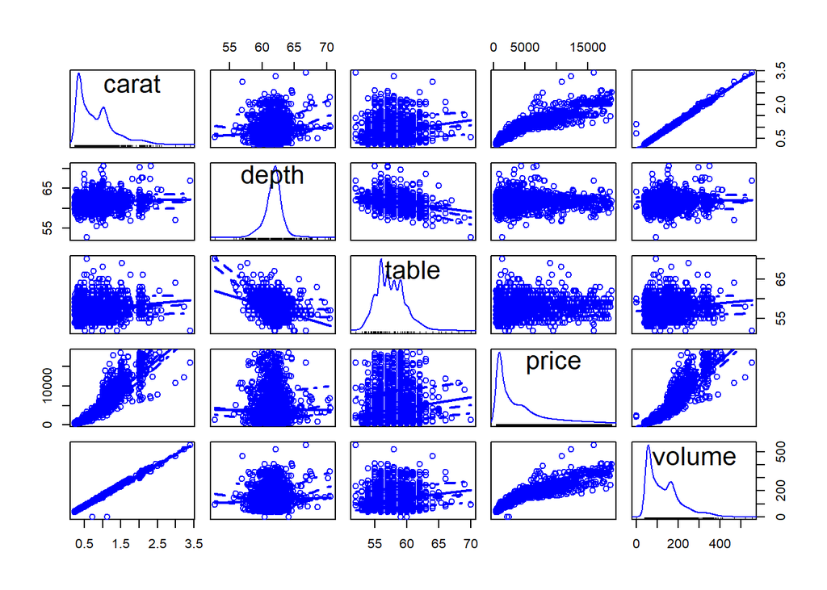

```r
scatterplotMatrix(litdata, spread=FALSE)
```

3. Для оценки качества регресионной модели разделим выборку на тестовую и обучающую:

```r
set.seed(1827)
split <- sample.split(mydata$price, SplitRatio = 0.75)
train <- subset(mydata, split == TRUE)
test <- subset(mydata, split == FALSE)
train_y <- train$price
train_x <- train%>%select(-price)%>%data.matrix()
test_x <- test%>%select(-price)%>%data.matrix()
```

4. Построим модель линейной регрессии:

```r
m_lm <- lm(price~carat + depth + table + volume,data = train)
summary(m_lm)
```

```
##
## Call:
## lm(formula = price ~ carat + depth + table + volume, data = train)
##
## Residuals:
##      Min       1Q   Median       3Q      Max
## -12296.4   -773.8    -24.7    543.4  11378.1
##
## Coefficients:
##              Estimate Std. Error t value Pr(>|t|)
## (Intercept) 10597.623   1099.730   9.637  < 2e-16 ***
## carat        3190.425    563.444   5.662 1.54e-08 ***
## depth        -121.052     13.286  -9.111  < 2e-16 ***
## table         -95.898      8.483 -11.304  < 2e-16 ***
## volume         29.198      3.480   8.391  < 2e-16 ***
## ---
## Signif. codes:  0 '***' 0.001 '**' 0.01 '*' 0.05 '.' 0.1 ' ' 1
##
## Residual standard error: 1531 on 8086 degrees of freedom
## Multiple R-squared:  0.853,  Adjusted R-squared:  0.8529
## F-statistic: 1.173e+04 on 4 and 8086 DF,  p-value: < 2.2e-16
```

```r
glance(m_lm)
```

```
## # A tibble: 1 x 11
##   r.squared adj.r.squared sigma statistic p.value    df  logLik    AIC
##       <dbl>         <dbl> <dbl>     <dbl>   <dbl> <int>   <dbl>  <dbl>
## 1     0.853         0.853 1531.    11727.       0     5 -70813. 1.42e5
## # ... with 3 more variables: BIC <dbl>, deviance <dbl>, df.residual <int>
```

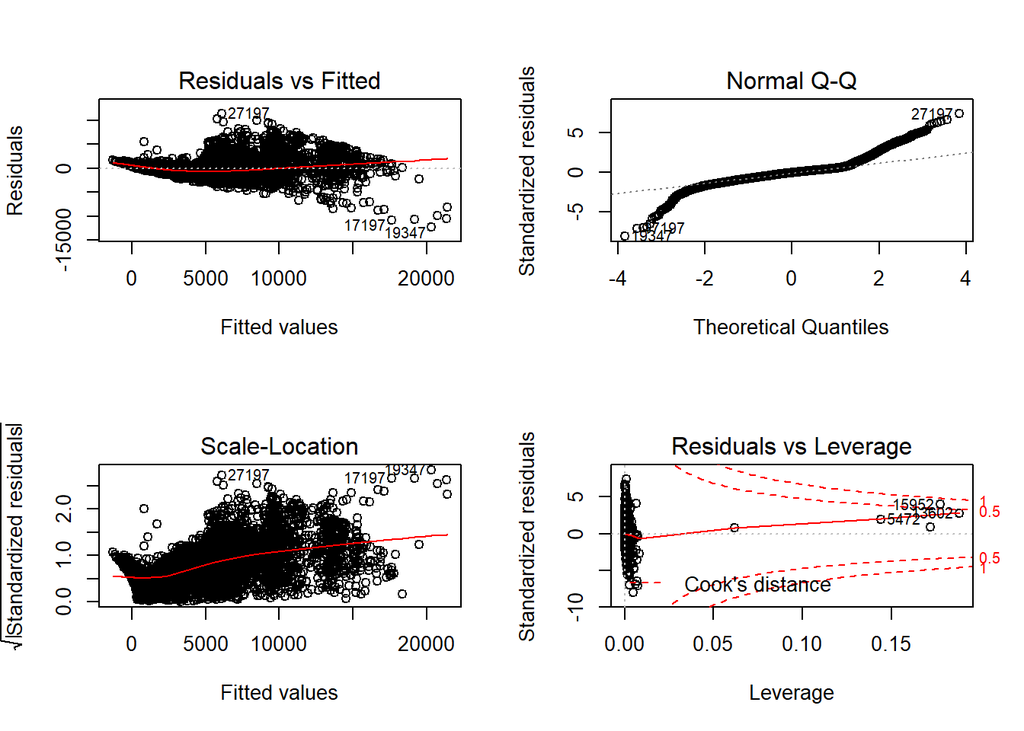

```r
par(mfrow=c(2,2))
plot(m_lm)
```

5. Для анализа мультиколлениарности вычислим значения коэффициентов увеличения дисперсии VIF:

```r
VIF(m_lm)
```

```
##      carat      depth      table     volume
## 243.127683   1.237970   1.241386 241.359211
```

> Поскольку коэфициенты больше 10, то мультиколлинеарность присутсвует.
6. Проверка выполнения условий Гаусса-Маркова:

Проверка несмещенности:

> H0: Математическое ожидание остатков равно нулю  
> H1: Математическое ожидание остатков не равно нулю

Вычислим t-расчётное и t-табличное

```r
a <- mean(m_lm$residuals)
b<-sd(m_lm$residuals, na.rm = FALSE)
n <- sqrt(13338)
tm <- a/b*n
str(tm)
```

```
##  num 2.53e-14
```

```r
qt(0.975,13337)
```

```
## [1] 1.960142
```

> t-расчётное меньше < t-табличного - нулевая гипотеза о равенстве математического ожидания остатков нулю подтверждается.

Проверка инвариантности дисперсии:

> H0: Отсутсвие гетероскедастичнсти  
> H1: Наличие гетероскедастичности

Проведем тест Бройша-Пагана

```r
bptest(m_lm)
```

```
##
##  studentized Breusch-Pagan test
##
## data:  m_lm
## BP = 1440.7, df = 4, p-value < 2.2e-16
```

> Так как значение p-value меньше 0.05, нулевая гипотеза о гомоскедастичности остатков не подтверждается.

Проверка отсутствия автокорреляции:

> H0: ρ=0 (т.е. автокорреляция остатков отсутствует)  
> H1: ρ>0 или ρ<0 (наличие положительной или отрицательной автокорреляции остатков)

Проведем тесты Бройша- Годфри и Дарбина-Уотсона:

```r
bgtest(m_lm)
```

```
##
##  Breusch-Godfrey test for serial correlation of order up to 1
##
## data:  m_lm
## LM test = 1537.7, df = 1, p-value < 2.2e-16
```

```r
dwtest(m_lm )
```

```
##
##  Durbin-Watson test
##
## data:  m_lm
## DW = 1.1545, p-value < 2.2e-16
## alternative hypothesis: true autocorrelation is greater than 0
```

> Поскольку значение p-value меньше 0.05 нулевая гипотеза об отсутствии автокорреляции остатков не подтверждается.

Проверка согласовнности остатков регрессии с нормальным законом:  
Рассмотрим графические тесты:

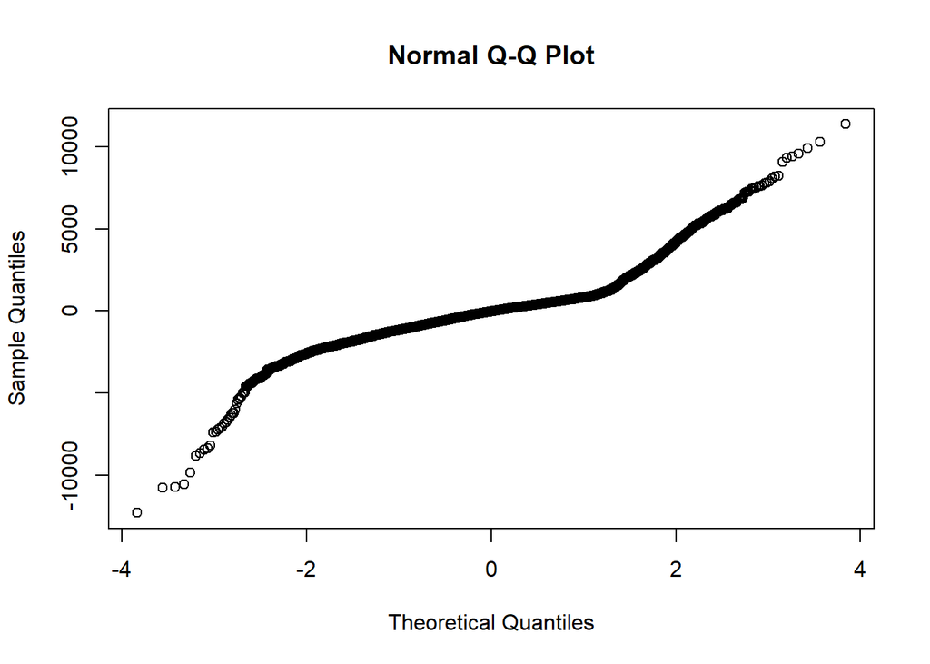

```r
qqnorm(m_lm$residuals)
```

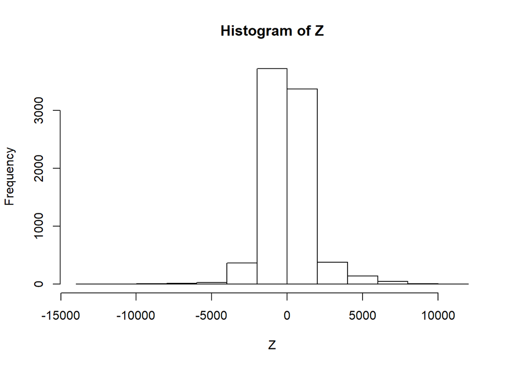

```r
Z<- m_lm$residuals
hist(Z)
```

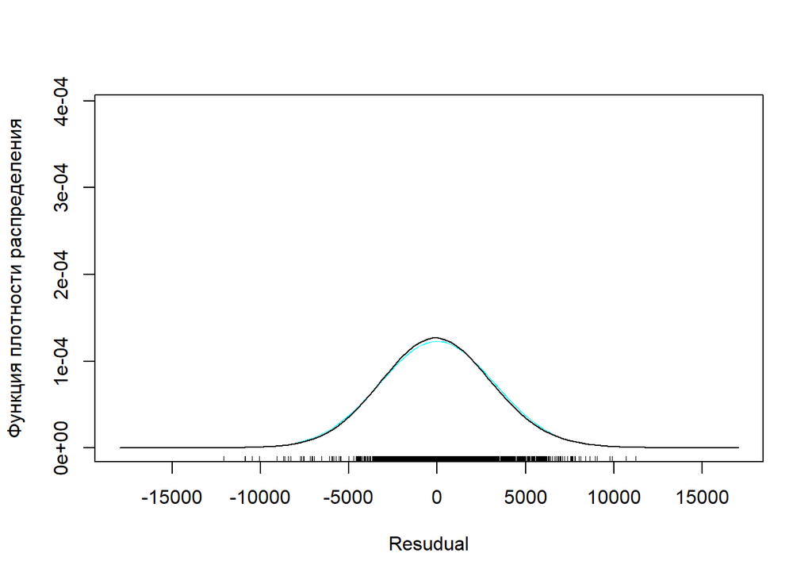

```r
sm.density(m_lm$residuals, model = "Normal",xlab = "Resudual", ylab = "Функция плотности распределения")
```

Рассмотрим параметрические тесты:  
Тест Лиллиефорса:

> Н0: распределение остатков не отлично от нормального  
> Н1: распределение остатков отлично от нормального

```r
lillie.test(m_lm$residuals)
```

```
##
##  Lilliefors (Kolmogorov-Smirnov) normality test
##
## data:  m_lm$residuals
## D = 0.1383, p-value < 2.2e-16
```

> Так как значение p-value меньше 0.05, нулевая гипотеза о согласии распределения остатков с нормальным законом распределения не принимается.
7. Построим прогноз по полученной модели на тестовой выборке

```r
test$predict <- predict(m_lm, test)
str(test)
```

```
## 'data.frame':    2697 obs. of  6 variables:
##  $ carat  : num  0.21 0.23 0.24 0.8 0.74 0.71 0.8 0.7 0.77 0.77 ...
##  $ depth  : num  59.8 63.8 62.5 61.7 61.3 60.7 61 63.2 61.2 62.2 ...
##  $ table  : num  61 55 57 58 56 56 57 60 58 56 ...
##  $ price  : int  326 352 355 2762 2769 2770 2772 2777 2780 2781 ...
##  $ volume : num  34.5 37.4 38.6 130.7 121.8 ...
##  $ predict: num  -814 -573 -541 3936 3723 ...
```

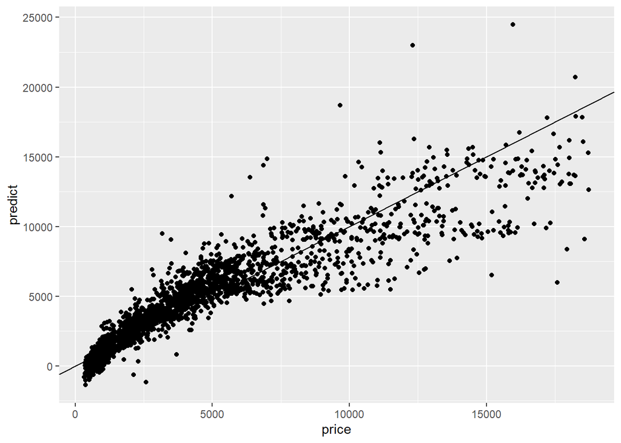

```r
ggplot(test, aes(x = price, y = predict)) + geom_point() + geom_abline()
```

8. Оценим параметры с помощью метода Ридж:

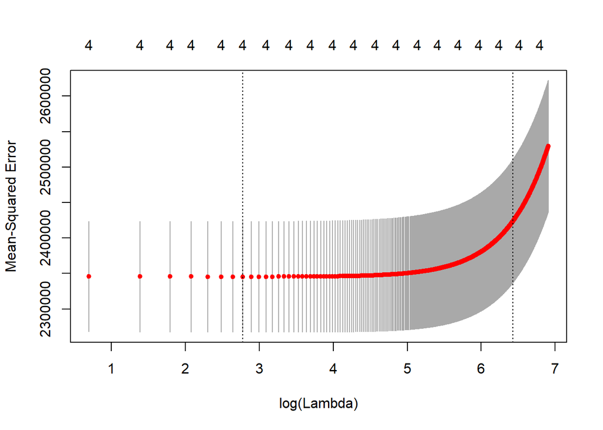

```r
set.seed(1877)
lambdas <- seq(0, 1000, by = 2)
cv_ridge <- cv.glmnet(train_x, train_y, alpha = 0, lambda = lambdas)
plot(cv_ridge)
```

Определим подходящие значения λ:

```r
cv_ridge$lambda.min
```

```
## [1] 16
```

```r
cv_ridge$lambda.1se
```

```
## [1] 618
```

Построим модель линейной регрессии с помощью метода Ридж:

```r
m_ridge <- glmnet(train_x, train_y, alpha = 0, lambda = cv_ridge$lambda.min)
coef(m_ridge)
```

```
## 5 x 1 sparse Matrix of class "dgCMatrix"
##                      s0
## (Intercept) 10936.56917
## carat        3890.83086
## depth        -124.93877
## table         -97.36452
## volume         24.77535
```

```r
m_ridge_1se <- glmnet(train_x, train_y, alpha = 0, lambda = cv_ridge$lambda.1se)
coef(m_ridge_1se)
```

```
## 5 x 1 sparse Matrix of class "dgCMatrix"
##                     s0
## (Intercept) 7069.65750
## carat       3634.38682
## depth        -89.74152
## table        -59.76340
## volume        22.74405
```

Построим прогноз для полученной модели на тестовой выборке:

```r
test$ridge <- predict(m_ridge, s = cv_ridge$lambda.min, newx = test_x)
str(test)
```

```
## 'data.frame':    2697 obs. of  7 variables:
##  $ carat  : num  0.21 0.23 0.24 0.8 0.74 0.71 0.8 0.7 0.77 0.77 ...
##  $ depth  : num  59.8 63.8 62.5 61.7 61.3 60.7 61 63.2 61.2 62.2 ...
##  $ table  : num  61 55 57 58 56 56 57 60 58 56 ...
##  $ price  : int  326 352 355 2762 2769 2770 2772 2777 2780 2781 ...
##  $ volume : num  34.5 37.4 38.6 130.7 121.8 ...
##  $ predict: num  -814 -573 -541 3936 3723 ...
##  $ ridge  : num [1:2697, 1] -802 -567 -531 3932 3721 ...
##   ..- attr(*, "dimnames")=List of 2
##   .. ..$ : chr  "2" "22" "27" "117" ...
##   .. ..$ : chr "1"
```

9. Оценим параметры модели с помощью метода Lasso

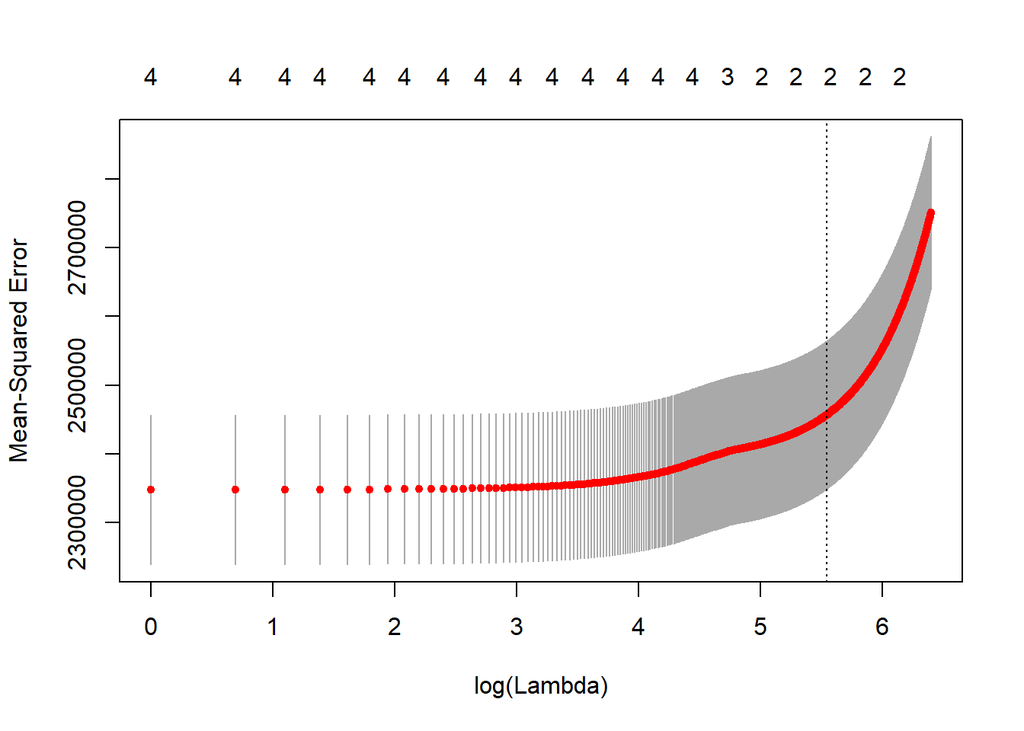

```r
set.seed(1886)
lambdas <- seq(0, 600, by = 1)
cv_lasso <- cv.glmnet(train_x, train_y, alpha = 1, lambda = lambdas)
plot(cv_lasso)
```

Определим подходящие значения λ:

```r
cv_lasso$lambda.min
```

```
## [1] 0
```

```r
cv_lasso$lambda.1se
```

```
## [1] 255
```

Построим модель линейной регрессии с помощью метода Lasso:

```r
m_lasso <- glmnet(train_x, train_y, alpha = 1, lambda = cv_lasso$lambda.min)
coef(m_lasso)
```

```
## 5 x 1 sparse Matrix of class "dgCMatrix"
##                      s0
## (Intercept) 11027.31538
## carat        3833.52685
## depth        -125.69057
## table         -98.37538
## volume         25.23422
```

```r
m_lasso_1se <- glmnet(train_x, train_y, alpha = 1, lambda = cv_lasso$lambda.1se)
coef(m_lasso_1se)
```

```
## 5 x 1 sparse Matrix of class "dgCMatrix"
##                      s0
## (Intercept) -1896.61164
## carat        1127.08128
## depth           .
## table           .
## volume         38.10088
```

Построим прогноз по полученной модели на тестовой выборке:

```r
test$lasso <- predict(m_lasso, s = cv_lasso$lambda.min, newx = test_x)
str(test)
```

```
## 'data.frame':    2697 obs. of  8 variables:
##  $ carat  : num  0.21 0.23 0.24 0.8 0.74 0.71 0.8 0.7 0.77 0.77 ...
##  $ depth  : num  59.8 63.8 62.5 61.7 61.3 60.7 61 63.2 61.2 62.2 ...
##  $ table  : num  61 55 57 58 56 56 57 60 58 56 ...
##  $ price  : int  326 352 355 2762 2769 2770 2772 2777 2780 2781 ...
##  $ volume : num  34.5 37.4 38.6 130.7 121.8 ...
##  $ predict: num  -814 -573 -541 3936 3723 ...
##  $ ridge  : num [1:2697, 1] -802 -567 -531 3932 3721 ...
##   ..- attr(*, "dimnames")=List of 2
##   .. ..$ : chr  "2" "22" "27" "117" ...
##   .. ..$ : chr "1"
##  $ lasso  : num [1:2697, 1] -814 -576 -541 3932 3723 ...
##   ..- attr(*, "dimnames")=List of 2
##   .. ..$ : chr  "2" "22" "27" "117" ...
##   .. ..$ : chr "1"
```

10. Рассчитаем метрики MAE (средняя абсолютная ошибка), RMSE (квадратный корень из среднеквадратичной ошибки), MAPE (средняя абсолютная ошибка в процентах) для моделей, полученных с использованием различных методов для оценки параметров.

```r
MAPE(x = test$predict, ref = test$price)
```

```
## [1] 0.3917599
```

```r
RMSE(x = test$predict, ref = test$price)
```

```
## [1] 1515.276
```

```r
MAE(x = test$predict, ref = test$price)
```

```
## [1] 983.3468
```

```r
MAPE(x = test$ridge, ref = test$price)
```

```
## [1] 0.3892067
```

```r
RMSE(x = test$ridge, ref = test$price)
```

```
## [1] 1514.51
```

```r
MAE(x = test$ridge, ref = test$price)
```

```
## [1] 981.3798
```

```r
MAPE(x = test$lasso, ref = test$price)
```

```
## [1] 0.3919691
```

```r
RMSE(x = test$lasso, ref = test$price)
```

```
## [1] 1515.023
```

```r
MAE(x = test$lasso, ref = test$price)
```

```
## [1] 983.3372
```

Результаты сравнения метрик

| Met | MAPE | RMSE | MAE |
| --- | --- | --- | --- |
| МНК | 0.3917599 | 1515.276 | 983.3468 |
| Ридж | 0.3892067 | 1514.51 | 981.3798 |
| Лассо | 0.3919691 | 1515.023 | 983.3372 |

Тест Рамсея:

> Н0: Спецификация модели является правильной  
> Н1: Спецификация модели является неправильной

```r
resettest(m_lm)
```

```
##
##  RESET test
##
## data:  m_lm
## RESET = 666.72, df1 = 2, df2 = 8084, p-value < 2.2e-16
```